**GITHUB PAGE**  
https://ballaghjoshua.github.io/

# Final Tutorial: Public Education and Policy in Louisiana

--- CMPS-3160 ---

--- Tulane University ---

--- By Josh Ballagh and Ellen Waller ---

--- Fall 2020 ---

## Introduction

**Disclaimer: This page is still under construction!**  
We will be making major updates/overhauls as the semester progresses. This is simply our current working version.  
The final version will be available 11/24/2020.

See the assignment project on the course webpage here: https://nmattei.github.io/cmps3160/projects/FinalTutorial/

For the final tutorial, we (Josh Ballagh and Ellen Waller) aim to examine a series of data sets that pertain to public education in Louisiana. Specifically, we will be looking at ACT results and graduation rates in Louisiana from 2005 to 2019. These academic markers are traditionally used to measure student and school performance, and they will be valuable in comparing the qualities of education that are available to children in different parishes and with different backgrounds.

When viewed at the aggregate level, this data tells a story of Louisiana education as a whole, providing overall average test scores and graduation rates. This, however, is not the entire story. To get a clearer picture of the state of Louisiana’s public education, it will be essential to look at how these academic markers differ across parishes, as well as how these markers vary across specific subgroups (minority students, students with disabilities, and economically disadvantaged students). Breaking down the data along these lines will give us the ability to answer key questions: Which parishes have the highest academic performance? Which ones have the lowest? Which have experienced the most growth in the past decade, and which have declined? Do the highest performing parishes also have the highest performing subgroups? Is an upwards trend of academic performance overall in the state caused by the improvement of all parishes, or just a select few either at the top or bottom end of the distribution? Are specific subgroups experiencing the same overall trends of the parish and state? If so, which subgroups? Which parishes are doing a better job setting up the success of these subgroups, and how does this correlate to funding? With this data broken down to the parish level, we will then also be able to analyze the data in the context of the parish itself. We can compare the academic markers to the parish demographics, indicators of wealth, average levels of parent education, and employment rates, ultimately looking at which factors may or may not correlate.

As we look at this data, it will be important to keep in mind policy changes that have impacted Louisiana’s public education system in the past decade. In 2012, Louisiana pushed a statewide initiative for major education reform that resulted in three acts being signed into law: the Talent Statute (allowing schools to base personnel decisions more greatly on teacher effectiveness), the Choice Law (allowing for greater parent/student choice in the educational process), and the Early Childhood Education Act (establishing stronger foundations for students in early childhood). With data both preceding and succeeding the establishment of this initiative, we can look at whether or not these reforms have had an impact on high school performance, and in what areas. Furthermore, in 2015, the Every Student Succeeds Act (ESSA) was passed into law by the US Federal Government, allowing states more independence in determining the standards that students are held to. It also requires a multiple-measure accountability system for each state, and requires that all schools provide college/career counseling and advanced placement courses for all students. What, if any, impact has this major shift in education policy had on the state of Louisiana?

We hope to tackle these questions and more!

```
I. School Performance Data
II. Income Data
III. ACT Scores by Parish
IV. ACT Scores by Demographic Subgroup
```

## Part I: School Performance Data

Our project will rely primarily on data published by the Louisiana Department of Education. For our first milestone, we have uploaded and tidied a dataset of primary and secondary school performance metrics in 2019 as published on the state's website here: https://louisianabelieves.com/resources/library/data-center

This briefing from the state helps provide further context to the dataset: https://www.louisianabelieves.com/docs/default-source/data-management/2018-2019-school-and-center-performance-briefing.pdf?sfvrsn=4829a1f_4

Now, let's load that data!

#### Import Libraries

So far, we have used the pandas library for creating dataframes and the pylab and seaborn libraries for conducting exploratory analysis through visualization. If we use any others, we'll list them out here!

```python
import pandas as pd
import matplotlib.pylab as plt
import numpy as np
import seaborn as sns
# we will likely need to import other stuff later!
```

#### Loading Excel Data

The LA Department of Education stored this data in an Excel file, split across three sheets by class: School, Alternative School, and Closed School. Lucky for us, pandas can easily read Excel files into dataframes! We'll just have to do some simple operations to tidy up our dataframe before we can use it.

```python
performance2019_df = pd.read_excel('2019-school-performance-scores.xlsx')
performance2019_df.head()
```

|  | Unnamed: 0 | Unnamed: 1 | Unnamed: 2 | Unnamed: 3 | Unnamed: 4 | Unnamed: 5 | Unnamed: 6 | Unnamed: 7 | Unnamed: 8 | Unnamed: 9 | ... | Unnamed: 34 | Unnamed: 35 | Unnamed: 36 | Unnamed: 37 | Unnamed: 38 | Unnamed: 39 | Unnamed: 40 | Unnamed: 41 | Unnamed: 42 | Unnamed: 43 |
| --- | --- | --- | --- | --- | --- | --- | --- | --- | --- | --- | --- | --- | --- | --- | --- | --- | --- | --- | --- | --- | --- |
| 0 | 2019 School Performance Scores and Letter Grades | NaN | NaN | NaN | NaN | NaN | NaN | NaN | NaN | NaN | ... | NaN | NaN | NaN | NaN | NaN | NaN | NaN | NaN | NaN | NaN |
| 1 | Updated 2/12/2020 | NaN | NaN | NaN | NaN | NaN | NaN | NaN | 2019 Letter Grade Equivalents for Key Indices | NaN | ... | NaN | NaN | NaN | NaN | NaN | NaN | NaN | NaN | NaN | NaN |
| 2 | Site Code | School | School System | School Type (El... | 2019 Letter Grade | 2019 SPS | 2018 Letter Grade | 2018 SPS | 2019 K8 & High School Assessment Letter Grade ... | 2019 K8 & High School Progress Letter Grade Eq... | ... | 2018 K8 & High School \nProgress Index | 2018 K8 Assessment Index | 2018 K8 Progress Index | 2018 Dropout Credit Accumulation Index | 2018 High School Assessment Index | 2018 High School Progress Index | 2018 ACT Index | Strength of Diploma (Graduation Index) (2016-2... | Cohort Graduation Rate Index (Points Earned f... | Cohort Graduation Rate (Actual Graduation Rate... |
| 3 | 001001 | Armstrong Middle School | Acadia Parish | Elementary/Middle School | C | 61.8 | D | 53.7 | D | C | ... | 67.5 | 43.6 | 67.5 | 126.3 | NaN | NaN | NaN | NaN | NaN | NaN |
| 4 | 001002 | Branch Elementary School | Acadia Parish | Elementary/Middle School | A | 92 | B | 87.8 | B | A | ... | 101.7 | 79.6 | 101.7 | 133.8 | NaN | NaN | NaN | NaN | NaN | NaN |

5 rows × 44 columns

#### Tidying Up

```python
performance2019_df.columns = performance2019_df.loc[2] # Assign our columns names, pulling them from Row 2
performance2019_df = performance2019_df[3:1270] # cut off the rows at top and bottom filled with NaN's and non-values
performance2019_df.rename(columns = {'2019 Letter Grade ': '2019 Letter Grade', '2019 SPS ' : '2019 SPS', '2018 Letter Grade ': '2018 Letter Grade', '2018 SPS ':'2018 SPS'}, errors = 'raise', inplace = True) #some of these column names have annoying whitespace tacked on - let's fix that
```

```python
performance2019_df.reset_index(drop = True, inplace = True) # reset the index for convenience
performance2019_df # And let's see our beautiful, tidied-up table!
```

| 2 | Site Code | School | School System | School Type (Elementary, Middle, High, Combination) | 2019 Letter Grade | 2019 SPS | 2018 Letter Grade | 2018 SPS | 2019 K8 & High School Assessment Letter Grade Equivalent | 2019 K8 & High School Progress Letter Grade Equivalent | ... | 2018 K8 & High School \nProgress Index | 2018 K8 Assessment Index | 2018 K8 Progress Index | 2018 Dropout Credit Accumulation Index | 2018 High School Assessment Index | 2018 High School Progress Index | 2018 ACT Index | Strength of Diploma (Graduation Index) (2016-2017 Cohort) | Cohort Graduation Rate Index (Points Earned for Cohort Graduation Rate) (2016-2017 Cohort) | Cohort Graduation Rate (Actual Graduation Rate) (2016-2017 Cohort) |
| --- | --- | --- | --- | --- | --- | --- | --- | --- | --- | --- | --- | --- | --- | --- | --- | --- | --- | --- | --- | --- | --- |
| 0 | 001001 | Armstrong Middle School | Acadia Parish | Elementary/Middle School | C | 61.8 | D | 53.7 | D | C | ... | 67.5 | 43.6 | 67.5 | 126.3 | NaN | NaN | NaN | NaN | NaN | NaN |
| 1 | 001002 | Branch Elementary School | Acadia Parish | Elementary/Middle School | A | 92 | B | 87.8 | B | A | ... | 101.7 | 79.6 | 101.7 | 133.8 | NaN | NaN | NaN | NaN | NaN | NaN |
| 2 | 001003 | Central Rayne Kindergarten School | Acadia Parish | Elementary/Middle School | C | 68.5 | C | 73.9 | D | A | ... | 102.9 | 64.2 | 102.9 | NaN | NaN | NaN | NaN | NaN | NaN | NaN |
| 3 | 001004 | Church Point Elementary School | Acadia Parish | Elementary/Middle School | C | 61.9 | C | 63.7 | D | B | ... | 77.6 | 59 | 77.6 | NaN | NaN | NaN | NaN | NaN | NaN | NaN |
| 4 | 001005 | Church Point High School | Acadia Parish | High School | B | 77.1 | B | 80.7 | D | C | ... | 71.8 | NaN | NaN | NaN | 62.9 | 71.8 | 62.1 | 93.9 | 99.4 | 89.5 |
| ... | ... | ... | ... | ... | ... | ... | ... | ... | ... | ... | ... | ... | ... | ... | ... | ... | ... | ... | ... | ... | ... |
| 1262 | WBR001 | Athlos Academy of Jefferson Parish | Athlos Academy of Jefferson Parish | Elementary/Middle School | F | 43.6 | NaN | NaN | F | D | ... | NaN | NaN | NaN | NaN | NaN | NaN | NaN | NaN | NaN | NaN |
| 1263 | WBU001 | Rosenwald Collegiate Academy | Orleans Parish | High School | B | 84.5 | NaN | NaN | C | A | ... | NaN | NaN | NaN | NaN | NaN | NaN | NaN | NaN | NaN | NaN |
| 1264 | WBV001 | Dwight D. Eisenhower Charter School | Orleans Parish | Elementary/Middle School | C | 63.8 | NaN | NaN | F | A | ... | NaN | NaN | NaN | NaN | NaN | NaN | NaN | NaN | NaN | NaN |
| 1265 | WJ5001 | Collegiate Baton Rouge | Collegiate Baton Rouge | High School | C | 64.1 | C | 64.4 | F | A | ... | 82.9 | NaN | NaN | NaN | 45.9 | 82.9 | NaN | NaN | NaN | NaN |
| 1266 | WZ8001 | GEO Prep Mid-City of Greater Baton Rouge | GEO Prep Mid-City of Greater Baton Rouge | Elementary/Middle School | T | 56 | T | 51 | F | A | ... | 92.2 | 30.4 | 92.2 | 134.2 | NaN | NaN | NaN | NaN | NaN | NaN |

1267 rows × 44 columns

### Exploring SPS Data

Let's see 2019 data on where Josh went to high school, the Louisiana School for Math, Science, and the Arts!

```python
lsmsa_data = performance2019_df.set_index("School").loc[
    "Louisiana School for Math Science & the Arts"]  # Grab LSMSA's data
performance2019_df['2019 SPS'] = performance2019_df['2019 SPS'].astype('float64') # convert column from string to float
performance2019_df['2018 SPS'] = performance2019_df['2018 SPS'].astype('float64')
mean_SPS = performance2019_df['2019 SPS'].mean()
max_SPS = performance2019_df['2019 SPS'].max()

print("The state's mean SPS was", mean_SPS,
      "in 2019. LSMSA's SPS that year was", lsmsa_data['2019 SPS'])
print("The max SPS was", max_SPS, "in 2019. I wonder who got that score?")

bf_data = performance2019_df.set_index(
    "School").loc["Benjamin Franklin High School"]
print(
    "It appears to be our old rivals, Benjamin Franklin in Baton Rouge. Their 2019 SPS was",
    bf_data['2019 SPS'])
```

```
The state's mean SPS was 73.65982636148384 in 2019. LSMSA's SPS that year was 127.1
The max SPS was 135.5 in 2019. I wonder who got that score?
It appears to be our old rivals, Benjamin Franklin in Baton Rouge. Their 2019 SPS was 135.5
```

Now that we've taken a look at some standout schools in the dataset, let's do some more analysis of the dataset as a whole.

```
Correlation between 2019 SPS and 2018 SPS by school:
```

```
0.9578086561077895
```

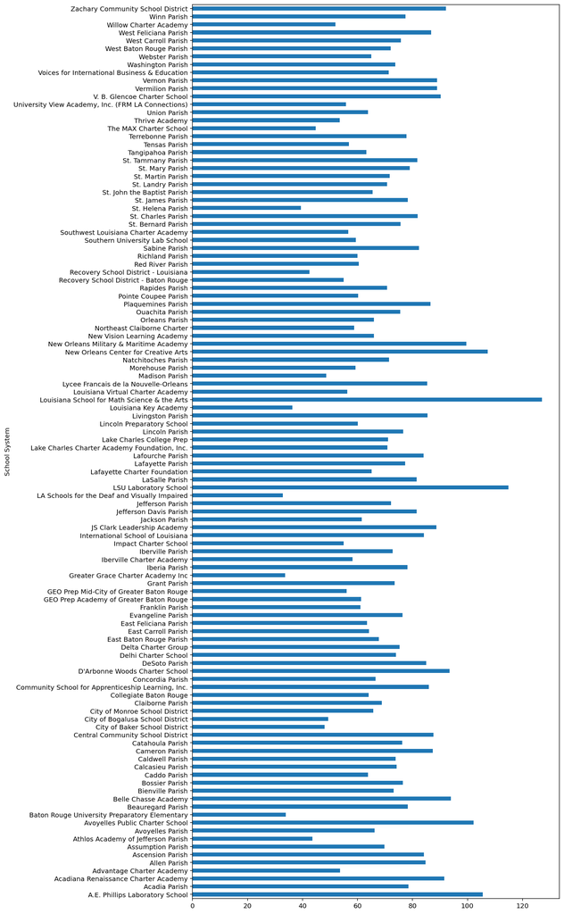

```python
# Plot mean 2019 SPS scores by parish
performance2019_df.groupby('School System')['2019 SPS'].mean().plot.barh(figsize = (10, 25))

# Some more useful information... Let's check the correlation between 2018 SPS and 2019 SPS
print("Correlation between 2019 SPS and 2018 SPS by school:")
performance2019_df['2019 SPS'].corr(performance2019_df['2018 SPS'])
```

As you can see above, 2019 SPS and 2018 SPS are VERY STRONGLY CORRELATED!

## Part II: Income Data

In the rest of this notebook, we will be loading additional datasets against which we will be comparing our school data. First up is data on income and unemployment by parish in 2018, taken from the USDA. The original dataset can be found here: https://data.ers.usda.gov/reports.aspx?ID=17828

```python
employment_df = pd.read_excel('UnemploymentReport.xlsx')
# For some reason, this file doesn't like to be read as an Excel file (despite that being what the Census distributes it as).
# Reading it as a CSV seems to work, though!
employment_df

# The year columns are unemployment rates as a percent.
# The first row contains the numbers for the state as a whole; each row after that observes a single parish.
```

|  | Unnamed: 0 | NaN | Unemployment Rate (percent) | None.1 | None.2 | None.3 | None.4 | None.5 | None.6 | None.7 | None.8 | Unnamed: 11 | Unnamed: 12 |
| --- | --- | --- | --- | --- | --- | --- | --- | --- | --- | --- | --- | --- | --- |
| 0 | FIPS | Name | 2011.0 | 2012.0 | 2013.0 | 2014.0 | 2015.0 | 2016.0 | 2017.0 | 2018.0 | 2019.0 | Median Household Income (2018) | % of State Median HH Income |
| 1 | 22000 | Louisiana | 7.8 | 7.1 | 6.7 | 6.4 | 6.3 | 6.1 | 5.1 | 4.9 | 4.8 | 48021 | 1 |
| 2 | 22001 | Acadia Parish, LA | 6.7 | 6.0 | 6.0 | 5.8 | 6.9 | 7.4 | 5.9 | 5.4 | 5.3 | 40484 | 0.843048 |
| 3 | 22003 | Allen Parish, LA | 9.1 | 8.0 | 7.5 | 7.2 | 7.0 | 6.4 | 5.3 | 5.7 | 5.7 | 44395 | 0.924491 |
| 4 | 22005 | Ascension Parish, LA | 7.0 | 6.1 | 5.6 | 5.3 | 5.1 | 4.9 | 4.3 | 4.1 | 4.1 | 77758 | 1.61925 |
| ... | ... | ... | ... | ... | ... | ... | ... | ... | ... | ... | ... | ... | ... |
| 63 | 22123 | West Carroll Parish, LA | 15.9 | 13.6 | 12.7 | 13.0 | 13.5 | 12.0 | 9.8 | 9.0 | 10.7 | 39332 | 0.819058 |
| 64 | 22125 | West Feliciana Parish, LA | 6.6 | 6.1 | 5.9 | 5.7 | 5.3 | 5.2 | 4.2 | 3.9 | 4.1 | 60296 | 1.25562 |
| 65 | 22127 | Winn Parish, LA | 9.4 | 8.5 | 8.2 | 7.5 | 8.5 | 7.8 | 6.4 | 6.2 | 6.3 | 40133 | 0.835739 |
| 66 | NaN | NaN | NaN | NaN | NaN | NaN | NaN | NaN | NaN | NaN | NaN | NaN | NaN |
| 67 | Sources: Bureau of Labor Statistics, Local Are... | NaN | NaN | NaN | NaN | NaN | NaN | NaN | NaN | NaN | NaN | NaN | NaN |

68 rows × 13 columns

Now that we've loaded in the table, let's clean it up a bit.

```python
employment_df.columns = employment_df.loc[0] # Assign columns proper names
employment_df = employment_df[1:66] # Cut off extra rows
```

```python
# To get rid of some annoying warnings that clutter the notebook:
pd.options.mode.chained_assignment = None  # default='warn'

employment_df.reset_index(drop = True, inplace = True) # Reset our index
employment_df['Median Household Income (2018)'] = employment_df['Median Household Income (2018)'].astype('float64') # set the type to float for doing math later

#Fix up the 'Name' column so that the strings are consistent with the school performance 2019 dataset
employment_df['Name'] = employment_df['Name'].str[:-4]
employment_df.at[0, 'Name'] = 'Louisiana'

employment_df
# Now let's look at our beautiful new table!
```

|  | FIPS | Name | 2011.0 | 2012.0 | 2013.0 | 2014.0 | 2015.0 | 2016.0 | 2017.0 | 2018.0 | 2019.0 | Median Household Income (2018) | % of State Median HH Income |
| --- | --- | --- | --- | --- | --- | --- | --- | --- | --- | --- | --- | --- | --- |
| 0 | 22000 | Louisiana | 7.8 | 7.1 | 6.7 | 6.4 | 6.3 | 6.1 | 5.1 | 4.9 | 4.8 | 48021.0 | 1 |
| 1 | 22001 | Acadia Parish | 6.7 | 6.0 | 6.0 | 5.8 | 6.9 | 7.4 | 5.9 | 5.4 | 5.3 | 40484.0 | 0.843048 |
| 2 | 22003 | Allen Parish | 9.1 | 8.0 | 7.5 | 7.2 | 7.0 | 6.4 | 5.3 | 5.7 | 5.7 | 44395.0 | 0.924491 |
| 3 | 22005 | Ascension Parish | 7.0 | 6.1 | 5.6 | 5.3 | 5.1 | 4.9 | 4.3 | 4.1 | 4.1 | 77758.0 | 1.61925 |
| 4 | 22007 | Assumption Parish | 12.1 | 9.7 | 8.3 | 7.7 | 7.9 | 8.4 | 7.3 | 6.6 | 6.1 | 48120.0 | 1.00206 |
| ... | ... | ... | ... | ... | ... | ... | ... | ... | ... | ... | ... | ... | ... |
| 60 | 22119 | Webster Parish | 10.1 | 9.6 | 9.6 | 8.7 | 8.8 | 8.5 | 6.9 | 6.1 | 6.1 | 35070.0 | 0.730305 |
| 61 | 22121 | West Baton Rouge Parish | 7.8 | 6.9 | 6.1 | 5.8 | 5.6 | 5.3 | 4.6 | 4.4 | 4.5 | 58205.0 | 1.21207 |
| 62 | 22123 | West Carroll Parish | 15.9 | 13.6 | 12.7 | 13.0 | 13.5 | 12.0 | 9.8 | 9.0 | 10.7 | 39332.0 | 0.819058 |
| 63 | 22125 | West Feliciana Parish | 6.6 | 6.1 | 5.9 | 5.7 | 5.3 | 5.2 | 4.2 | 3.9 | 4.1 | 60296.0 | 1.25562 |
| 64 | 22127 | Winn Parish | 9.4 | 8.5 | 8.2 | 7.5 | 8.5 | 7.8 | 6.4 | 6.2 | 6.3 | 40133.0 | 0.835739 |

65 rows × 13 columns

### SPS Scores vs. Median Household Income (2018)

Now let's see if there's a relationship between median household income and SPS.

Much of this integration process is necessary because of the relationship between school systems and parishes in Louisiana. The set of all school systems != the set of all parishes. Every parish has a school system, but not every school system belongs to a parish!

```python
system_means_2018 = performance2019_df.groupby('School System')['2018 SPS'].mean() # Series of school system mean SPS for 2018
system_means_2019 = performance2019_df.groupby('School System')['2019 SPS'].mean() # Series of school system mean SPS for 2019
```

|  | Mean SPS 2018 | Mean SPS 2019 | Median Household Income 2018 |
| --- | --- | --- | --- |
| Mean SPS 2018 | 1.000000 | 0.976768 | 0.523945 |
| Mean SPS 2019 | 0.976768 | 1.000000 | 0.546562 |
| Median Household Income 2018 | 0.523945 | 0.546562 | 1.000000 |

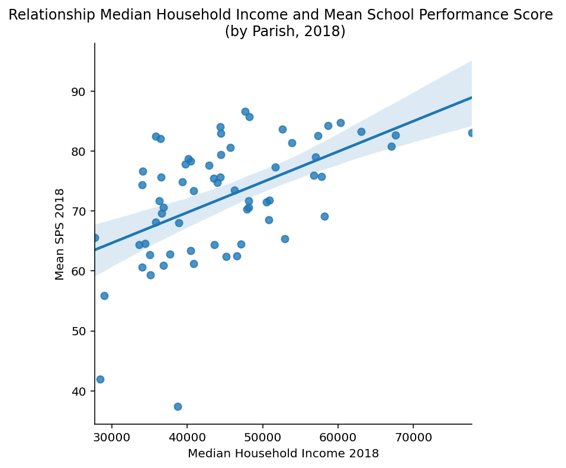

```python
# Make a list of parishes and a new dataframe
parishes = employment_df['Name'].unique() # List of Parish names in Louisiana
parishes_df = pd.DataFrame(parishes, columns = ['Name'])
parishes_df = parishes_df[1:] # Drop "Louisiana", as we only want parishes in this dataframe

# Construct series of data to add to our dataframe:
parish_median_income = employment_df['Median Household Income (2018)'][1:].tolist()
parish_means_2018 = []
parish_means_2019 = []

# Currently, De Soto and La Salle parishes are not showing up in our system means lists.
# There may be a string matching error. We'll need to account for it!
for parish in parishes:
    if parish in system_means_2018:
        parish_means_2018.append(system_means_2018[parish])
    if parish in system_means_2019:
        parish_means_2019.append(system_means_2019[parish])
    if parish == 'De Soto Parish':
        parish_means_2018.append(system_means_2018['DeSoto Parish'])
        parish_means_2019.append(system_means_2019['DeSoto Parish'])
    if parish == 'La Salle Parish':
        parish_means_2018.append(system_means_2018['LaSalle Parish'])
        parish_means_2019.append(system_means_2019['LaSalle Parish'])


#plt.plot(df1.start_datetime, df1.speed.astype(float),'b+')

# Add series to parishes_df
parishes_df['Mean SPS 2018'] = parish_means_2018
parishes_df['Mean SPS 2019'] = parish_means_2019
parishes_df['Median Household Income 2018'] = parish_median_income

# Plot 2018 relationship!
sns.lmplot(x='Median Household Income 2018',y='Mean SPS 2018',data = parishes_df,fit_reg=True)
ax = plt.gca()
ax.set_title("Relationship Median Household Income and Mean School Performance Score \n (by Parish, 2018)")

parishes_df.corr() # display correlations between variables
```

#### Making sense of the relationship

There is a moderate correlation between Mean SPS and Median Household Income by parish, at about 52%. This relationship is not particularly strong, but it does exist.

We suspect that at a more granular level, the relationship between SPS and median household income would be stronger. In this case, one would need to look on a school-by-school basis, examining median household income of students enrolled at the school. However, this data is hard to come by, if it is available at all!

This logically follows. In a given school system, there can exist both the "nice" schools located in wealthier neighborhoods and lower-scoring schools located in poorer neighborhoods. Examining the strength of this relationship in a given parish would make for a great case study in the future, but is currently beyond the scope of our project.

## Part III: Analyzing ACT Scores by Parish (2020)

Now we're going to look at ACT scores, focusing more on how they are broken down by parish, and whether or not the scores of parishes correlate with an inherent aspects of the parish. To do this, we will read in two more data frames from the LA Dept of Education. One is the ACT Scores of 2020 broken down by parish, and the other is student attributes data, also broken down by parish. We will combine these in order to have a data frame that contains information not only on student attributes, but also student scores, so that we can look at correlations.

```python
# load up 2020 Parish ACT data
ParishACT20df = pd.read_excel('ACT-Scores---Class-of-2020.xlsx')

# clean 2020 Parish ACT data:

# first, we will rename the columns
ParishACT20df.columns = ['School System Code','School System','2019-2020 Student Count','2019/20 Average ACT']

# get rid of the first few rows, which are unnecessary to us
for x in range(0, 5):
    ParishACT20df = ParishACT20df.reindex(ParishACT20df.index.drop(0)).reset_index(drop=True)

# load up 2020 Student Attributes data
Students20Df = pd.read_excel('feb-2020-multi-stats-(total-by-site-and-school-system).xlsx')

# clean students attributes data:

# get rid of unnecessary rows
for x in range(0, 6):
    Students20Df = Students20Df.reindex(Students20Df.index.drop(0)).reset_index(drop=True)

# rename the columns
Students20Df.columns = ['School System','School System Name','Sites Reporting','Total Enrollment',\
                      '% Female','% Male','American Indian','Asian','Black','Hispanic','Hawaiian/Pacific Islander',\
                      'White','Multiple Races (Non-Hispanic)','Minority','% Fully English Proficient',\
                      '% Limited English Proficiency','Infants (Sp Ed)','Pre-School (Sp Ed)','Pre-K (Reg Ed)',\
                      'Kindegarten','Grade 1','Grade 2','Grade 3','Grade 4','Grade 5','Grade 6','Grade 7',\
                      'Grade 8','Grade 9','Grade T9','Grade 10','Grade 11','Grade 12','Extension Academy',\
                      '% Economically Disadvantaged']


# now we will merge StudentsDf and ParishACTdf into a singular dataset, merging on School System

# first, set index of StudentsDf to be School System
Students20Df = Students20Df.set_index('School System')
ParishACT20df = ParishACT20df.set_index('School System Code')

# Perform inner merge on index
Parishes2020 = pd.merge(ParishACT20df, Students20Df, left_index=True, right_index=True)

# display the data frame, which now possesses both student attributes and ACT scores (2020), broken down by parish.
Parishes2020
```

|  | School System | 2019-2020 Student Count | 2019/20 Average ACT | School System Name | Sites Reporting | Total Enrollment | % Female | % Male | American Indian | Asian | ... | Grade 6 | Grade 7 | Grade 8 | Grade 9 | Grade T9 | Grade 10 | Grade 11 | Grade 12 | Extension Academy | % Economically Disadvantaged |
| --- | --- | --- | --- | --- | --- | --- | --- | --- | --- | --- | --- | --- | --- | --- | --- | --- | --- | --- | --- | --- | --- |
| 001 | Acadia Parish | 588 | 18.1 | Acadia Parish | 32 | 9738 | 0.489628 | 0.510372 | 15 | 17 | ... | 729 | 732 | 667 | 675 | 96 | 653 | 533 | 622 | 0 | 0.707127 |
| 002 | Allen Parish | 252 | 18.9 | Allen Parish | 12 | 4159 | 0.47848 | 0.52152 | 36 | 44 | ... | 332 | 349 | 306 | 270 | 28 | 253 | 274 | 264 | 0 | 0.682856 |
| 003 | Ascension Parish | 1450 | 19.9 | Ascension Parish | 29 | 23253 | 0.483637 | 0.516363 | 55 | 314 | ... | 1729 | 1860 | 1772 | 1701 | 115 | 1768 | 1678 | 1361 | 0 | 0.568099 |
| 004 | Assumption Parish | 218 | 18.1 | Assumption Parish | 9 | 3292 | 0.500304 | 0.499696 | 9 | 12 | ... | 224 | 254 | 234 | 211 | 49 | 237 | 205 | 235 | 0 | 0.717801 |
| 005 | Avoyelles Parish | 285 | 16.1 | Avoyelles Parish | 11 | 5124 | 0.477557 | 0.522443 | 52 | 21 | ... | 324 | 337 | 357 | 433 | 46 | 432 | 324 | 287 | 0 | 0.815964 |
| ... | ... | ... | ... | ... | ... | ... | ... | ... | ... | ... | ... | ... | ... | ... | ... | ... | ... | ... | ... | ... | ... |
| 066 | City of Bogalusa School District | 86 | 15.1 | City of Bogalusa School District | 4 | 1912 | 0.478033 | 0.521967 | 6 | 11 | ... | 163 | 159 | 146 | 121 | 5 | 102 | 116 | 101 | 0 | 0.925209 |
| 067 | Zachary Community School District | 367 | 21.6 | Zachary Community School District | 8 | 5583 | 0.487014 | 0.512986 | 1 | 59 | ... | 428 | 453 | 423 | 390 | 37 | 384 | 387 | 383 | 0 | 0.524091 |
| 068 | City of Baker School District | 78 | 14.7 | City of Baker School District | 4 | 1285 | 0.471595 | 0.528405 | 2 | 2 | ... | 101 | 83 | 114 | 98 | 30 | 121 | 106 | 95 | 0 | 0.978988 |
| 069 | Central Community School District | 297 | 19.6 | Central Community School District | 6 | 4869 | 0.481208 | 0.518792 | 9 | 60 | ... | 413 | 387 | 378 | 328 | 49 | 348 | 376 | 312 | 0 | 0.5038 |
| RBR | Recovery School District-Baton Rouge | 69 | 13.8 | Recovery School District - Baton Rouge | 6 | 2111 | 0.49171 | 0.50829 | 1 | 4 | ... | 284 | 284 | 277 | 75 | 7 | 88 | 100 | 90 | 0 | 0.961156 |

70 rows × 37 columns

|  | 2019/20 Average ACT | % Economically Disadvantaged |
| --- | --- | --- |
| 2019/20 Average ACT | 1.000000 | -0.864122 |
| % Economically Disadvantaged | -0.864122 | 1.000000 |

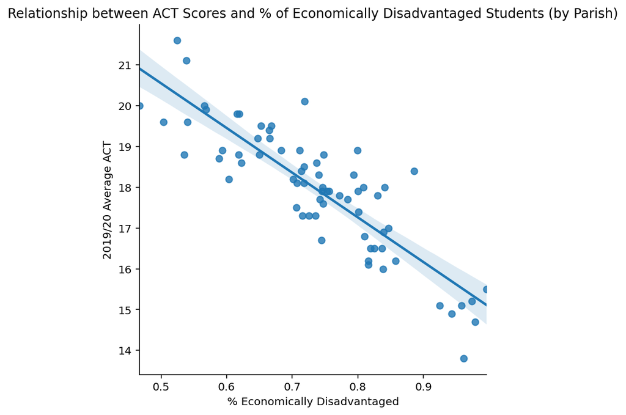

```python
# Now that this data is all housed in a singular data frame, we can look to see if there is correlation
# First, we are going to investigate the relationship between ACT scores of a parish and the percent of economically disadvantaged students in that parish

# Cast ACT and % Economically Disadvantaged to Numeric
Parishes2020["2019/20 Average ACT"] = pd.to_numeric(Parishes2020["2019/20 Average ACT"])
Parishes2020['% Economically Disadvantaged'] = pd.to_numeric(Parishes2020['% Economically Disadvantaged'])


# using seaborn, we will plot this relationship

sns.lmplot(x='% Economically Disadvantaged',y='2019/20 Average ACT',data=Parishes2020,fit_reg=True)
ax = plt.gca()
ax.set_title("Relationship between ACT Scores and % of Economically Disadvantaged Students (by Parish)")

# look at correlation numerically
Parishes2020.corr()
```

## Part IV: Analyzing ACT Scores by Subgroups (2012 - 2020)

```python
## read in the 2020 Subgroup ACT data
SubACT20df = pd.read_excel('2020-state-district-act-subgroup-performance.xlsx')
SubACT20df.head()

# now we will tidy some of this up

# first, we will rename the columns
SubACT20df.columns = ['School System Code', 'School System Name (Parish)','Subgroup','ACT',
              '# Students Scoring 18+','# Students Scoring 21+']

# get rid of the first few rows, which are unnecessary to us
for x in range(0, 4):
    SubACT20df = SubACT20df.reindex(SubACT20df.index.drop(0)).reset_index(drop=True)

# now, I'll replace the '~' with NaNs
SubACT20df = SubACT20df.replace('~', np.nan)

# convert 2020 ACT scores to numeric
SubACT20df["ACT"] = pd.to_numeric(SubACT20df["ACT"])



# read in the 2019 Subgroup ACT data
SubACT19df = pd.read_excel('2019-state-district-act-subgroup-performance.xlsx')
SubACT19df.head()

# first, we will rename the columns
SubACT19df.columns = ['School System Code', 'School System Name (Parish)','Subgroup','ACT',
              '# Students Scoring 18+','# Students Scoring 21+']

# get rid of the first few rows, which are unnecessary to us
for x in range(0, 3):
    SubACT19df = SubACT19df.reindex(SubACT19df.index.drop(0)).reset_index(drop=True)

# now, I'll replace the '~' with NaNs
SubACT19df = SubACT19df.replace('~', np.nan)

# Now we have two dataframes with 2019 ACT Scores and 2020 ACT Scores.
# Let's look at the 2020 ACT Dataframe to get an idea of what it looks like!
SubACT20df
```

|  | School System Code | School System Name (Parish) | Subgroup | ACT | # Students Scoring 18+ | # Students Scoring 21+ |
| --- | --- | --- | --- | --- | --- | --- |
| 0 | LA | Louisiana Statewide | Total Population | 18.7 | 21735 | 13331 |
| 1 | LA | Louisiana Statewide | American Indian or Alaska Native | 18.4 | 144 | 75 |
| 2 | LA | Louisiana Statewide | Asian | 23.3 | 667 | 543 |
| 3 | LA | Louisiana Statewide | Black or African American | 16.5 | 5739 | 2483 |
| 4 | LA | Louisiana Statewide | Hispanic/Latino | 17.6 | 1034 | 581 |
| ... | ... | ... | ... | ... | ... | ... |
| 925 | RBR | Recovery School District - Baton Rouge | Economically Disadvantaged | 13.7 | <10 | <10 |
| 926 | RBR | Recovery School District - Baton Rouge | Students with Disabilities | NaN | NaN | NaN |
| 927 | RBR | Recovery School District - Baton Rouge | Female | 13.7 | <10 | <10 |
| 928 | RBR | Recovery School District - Baton Rouge | Male | 13.8 | <10 | <10 |
| 929 | RBR | Recovery School District - Baton Rouge | Homeless | NaN | NaN | NaN |

930 rows × 6 columns

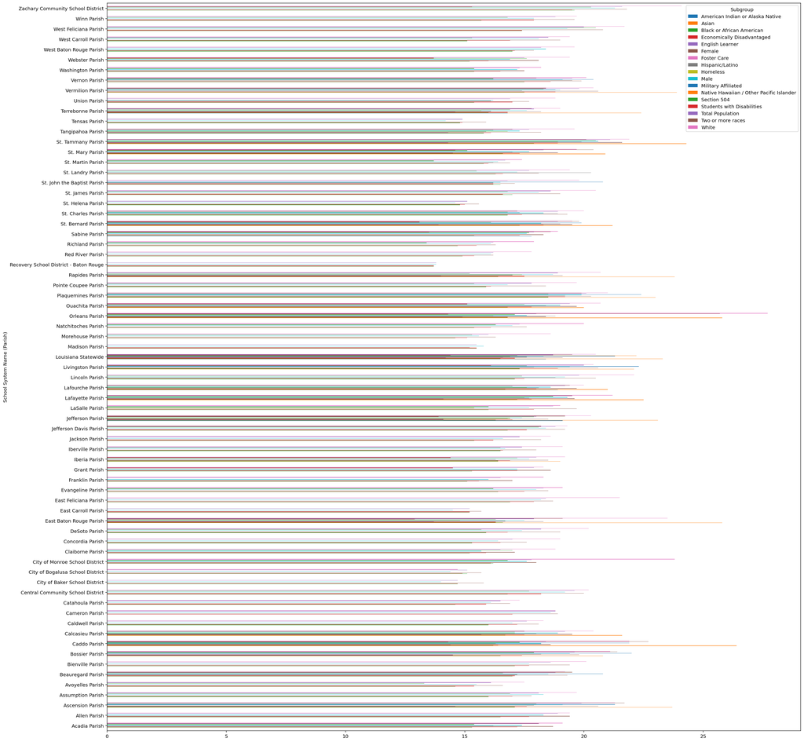

```python
# With the 2020 dataframe read in, we can start performing some analysis of the current performance of particular subgroups

# create pivot table of 2020 Subgroup ACT data
SubACT20df.pivot_table(
    index="School System Name (Parish)", columns=["Subgroup"],
    values="ACT", aggfunc=np.mean
).plot.barh(figsize = (26,28))
```

In theory, this data visualization would give you an idea of how each subgroup within a parish is performing on the ACT. However, as you can see, it's quite crowded and hard to make sense of. Instead, let's focus on just a particular subgroup, and order the scores, to get more of a sense of what story this data can tell.

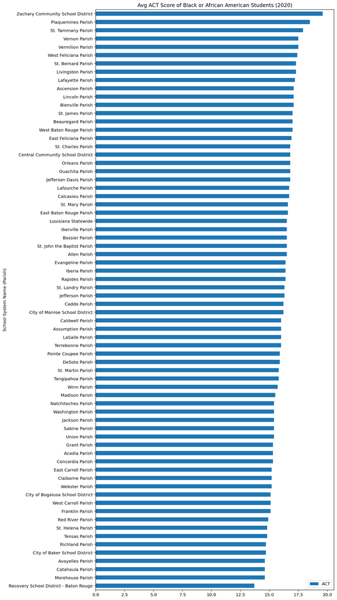

```python
# we will focus on the subgroup of Black/African American students

SubACT20df[SubACT20df.Subgroup == "Black or African American"]\
    .sort_values("ACT").\
    plot(x="School System Name (Parish)",y=["ACT"],kind="barh",figsize = (10, 25),\
    title="Avg ACT Score of Black or African American Students (2020)")
```

The graphic above gives a sense of how the subgroup of Black/African American students perform on the ACT, as broken down by parish. Because the graphic is order, we can see which parish has the highest subgroup score on the ACT, and which has the lowest. The scores themselves though do not tell a complete story. Do the schools that have the highest ACT scores of Black students also have the lowest disparity between Black students' scores and overall average scores? To find this out, we need to calculate disparity (difference between average ACT score of a parish and average ACT score of a particular subgroup within a parish). Unfortunately the 2020 Subgroup ACT Scores data frame does not already that data logged, so we will have to perform some operations on the data frame in order to find and log it.

```python
# Here we will alter the 2020 Subgroup ACT Scores dataframe in order to log the disparity between each subgroup's score and the average score of their parish

# We will do this by extracting a parish's overall average score from the data frame, creating a dictionary that possesses parishes as keys and the overall average scores as their values. This dictionary will then be used fill a new column, and that new column will then be used computer the disparity value of any particular subgroup of any particular parish.

# create new column
SubACT20df['Overall Avg Score'] = SubACT20df['School System Name (Parish)']

# create dictionary containing average scores, then use dictionary to fill new column of SubACT20df
new = SubACT20df[SubACT20df.Subgroup == "Total Population"][["School System Name (Parish)","ACT"]].copy()
dict_scores = dict(zip(new["School System Name (Parish)"], new["ACT"]))
dict_scores
SubACT20df.replace({"Overall Avg Score": dict_scores},inplace=True)
SubACT20df["Overall Avg Score"] = pd.to_numeric(SubACT20df["Overall Avg Score"])

# using new column that was added, we can now create a column that computes the disparity between a subgroup's score and the average score of their parish.
SubACT20df["Disparity"] = SubACT20df["ACT"] - SubACT20df["Overall Avg Score"]

# We'll call the dataframe, and now in the newly created last column "Disparity" you can see the change that has been
# For example, by looking at the data frame you can see that the statewide score of the Hispanic/Latinx subgroup is 1.1 less than the statewide score of the total population
SubACT20df
```

|  | School System Code | School System Name (Parish) | Subgroup | ACT | # Students Scoring 18+ | # Students Scoring 21+ | Overall Avg Score | Disparity |
| --- | --- | --- | --- | --- | --- | --- | --- | --- |
| 0 | LA | Louisiana Statewide | Total Population | 18.7 | 21735 | 13331 | 18.7 | 0.0 |
| 1 | LA | Louisiana Statewide | American Indian or Alaska Native | 18.4 | 144 | 75 | 18.7 | -0.3 |
| 2 | LA | Louisiana Statewide | Asian | 23.3 | 667 | 543 | 18.7 | 4.6 |
| 3 | LA | Louisiana Statewide | Black or African American | 16.5 | 5739 | 2483 | 18.7 | -2.2 |
| 4 | LA | Louisiana Statewide | Hispanic/Latino | 17.6 | 1034 | 581 | 18.7 | -1.1 |
| ... | ... | ... | ... | ... | ... | ... | ... | ... |
| 925 | RBR | Recovery School District - Baton Rouge | Economically Disadvantaged | 13.7 | <10 | <10 | 13.8 | -0.1 |
| 926 | RBR | Recovery School District - Baton Rouge | Students with Disabilities | NaN | NaN | NaN | 13.8 | NaN |
| 927 | RBR | Recovery School District - Baton Rouge | Female | 13.7 | <10 | <10 | 13.8 | -0.1 |
| 928 | RBR | Recovery School District - Baton Rouge | Male | 13.8 | <10 | <10 | 13.8 | 0.0 |
| 929 | RBR | Recovery School District - Baton Rouge | Homeless | NaN | NaN | NaN | 13.8 | NaN |

930 rows × 8 columns

Now that we have this metric, we can focus on the question that we asked before. Do the schools that have the highest ACT scores of Black students also have the lowest disparity between Black students' scores and overall average scores? Let us plot the disparity broken down by parish to see.

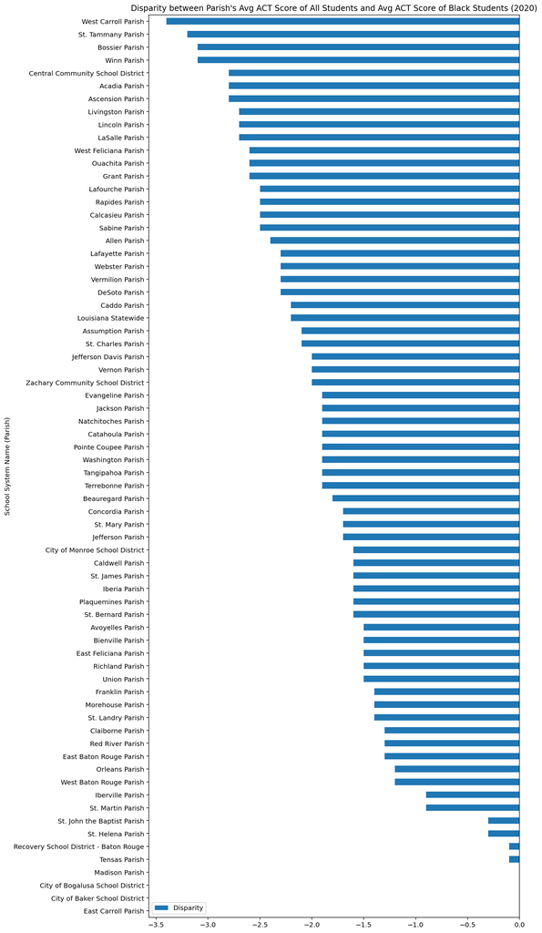

```python
# plot disparity between Black/AfricanAmerican subgroup ACT score to Total Population ACT score

SubACT20df[SubACT20df.Subgroup == "Black or African American"]\
    .sort_values("Disparity",ascending=False).\
    plot(x="School System Name (Parish)",y=["Disparity"],kind="barh",figsize = (10, 25),\
    title="Disparity between Parish's Avg ACT Score of All Students and Avg ACT Score of Black Students (2020)")
```

From this visualization of the disparity of ACT scores for the particular subgroup of Black/African American students, we are able to see a few things. When comparing this graphic with the graphic directly preceding, we can see that even though Zachary Community School District has the highest average ACT score of Black/African American students among parishes, it does not have the lowest level of disparity of scores. Instead, it falls in the middle. Meanwhile, the parishes with some of the lowest disparity (Tensas, St. Helena) don't necessarily have the highest average scores of Black students. In fact, they fall in the lowest third of parishes when numerically ordering the average ACT scores of Black students.